# Author: Jinad Patel

# Email: jinadpatel@gmail.com

# GitHub URL: https://github.com/GreatLearningAIML1/gl-pgp-aiml-uta-intl-may20-jinadpatel/tree/master/Thera_bank_Project2

# Data Description:

The dataset contains data on 5000 customers. The data include customer demographic information (age, income, etc.), the customer's relationship with the bank (mortgage, securities account, etc.), and the customer response to the last personal loan campaign (Personal Loan). Among these 5000 customers, only 480 (= 9.6%) accepted the personal loan that was offered to them in the earlier campaign.

# Domain:

Banking

# Context:

This case is about a bank (Thera Bank) whose management wants to explore ways of converting its liability customers to personal loan customers (while retaining them as depositors). A campaign that the bank ran last year for liability customers showed a healthy conversion rate of over 9% success. This has encouraged the retail marketing department to devise campaigns with better target marketing to increase the success ratio with a minimal budget.

# Attribute Information:

- ID: Customer ID
- Age: Customer's age in completed years
- Experience: #years of professional experience
- Income: Annual income of the customer
- ZIP Code: Home Address ZIP code.
- Family: Family size of the customer
- CCAvg: Avg. spending on credit cards per month
- Education: Education Level. 1: Undergrad; 2: Graduate; 3: Advanced/Professional
- Mortgage: Value of house mortgage if any.
- Personal Loan: Did this customer accept the personal loan offered in the last campaign?
- Securities Account: Doesthe customer have a securities account with the bank?
- CD Account: Doesthe customer have a certificate of deposit (CD) account with the bank?
- Online: Does the customer use internet banking facilities?
- Credit card: Does the customer use a credit card issued by the bank?

# Learning Outcomes:

- Exploratory Data Analysis
- Preparing the data to train a model
- Training and making predictions using a classificationmodel
- Model evaluation

# Objective:

The classification goal is to predict the likelihood of a liability customer buying personal loans.

# Step 1: Import the datasets and libraries, check datatype, statistical summary, shape, null values or incorrect imputation. (5 marks)

## Import the libraries

```python
# Ignore warnings
import warnings
warnings.filterwarnings('ignore')

# Libraries

# Data manipulation libraries
import numpy as np
import pandas as pd

# Visualization library
import matplotlib.pyplot as plt
%matplotlib inline
import seaborn as sns

sns.set_color_codes("dark")

# sklearn libraries for model building, statistical analysis etc.
from sklearn.linear_model import LogisticRegression
from sklearn.model_selection import train_test_split
from sklearn.metrics import confusion_matrix,recall_score,precision_score,mean_absolute_error,mean_squared_error,r2_score,f1_score,roc_auc_score,classification_report,roc_curve

from sklearn.preprocessing import RobustScaler

# custom display output
from IPython.display import display, HTML

import os,sys
from scipy import stats

# Stats model
import statsmodels.api as sm

# calculate accuracy measures and confusion matrix
from sklearn import metrics
```

```python
# Adjust pandas display and formatting settings

# Remove scientific notations and display numbers with 2 decimal points instead
pd.options.display.float_format = '{:,.2f}'.format

# Increase cell width
from IPython.core.display import display, HTML
display(HTML("<style>.container { width:98% !important; }</style>"))

# Update default style and size of charts
plt.style.use('ggplot')
plt.rcParams['figure.figsize'] = [20, 15]

# Increase max number of rows and columns to display in pandas tables
pd.set_option('display.max_columns', 500)
pd.set_option('display.max_rows', 500)
```

## Import Dataset

```python
dataset = pd.read_csv('Bank_Personal_Loan_Modelling.csv')
```

```python
# See first 5 rows of teh dataset
dataset.head()
```

|  | ID | Age | Experience | Income | ZIP Code | Family | CCAvg | Education | Mortgage | Personal Loan | Securities Account | CD Account | Online | CreditCard |
| --- | --- | --- | --- | --- | --- | --- | --- | --- | --- | --- | --- | --- | --- | --- |
| 0 | 1 | 25 | 1 | 49 | 91107 | 4 | 1.60 | 1 | 0 | 0 | 1 | 0 | 0 | 0 |
| 1 | 2 | 45 | 19 | 34 | 90089 | 3 | 1.50 | 1 | 0 | 0 | 1 | 0 | 0 | 0 |
| 2 | 3 | 39 | 15 | 11 | 94720 | 1 | 1.00 | 1 | 0 | 0 | 0 | 0 | 0 | 0 |
| 3 | 4 | 35 | 9 | 100 | 94112 | 1 | 2.70 | 2 | 0 | 0 | 0 | 0 | 0 | 0 |
| 4 | 5 | 35 | 8 | 45 | 91330 | 4 | 1.00 | 2 | 0 | 0 | 0 | 0 | 0 | 1 |

## Data Analysis

```python
# Shape of dataset
dataset.shape
```

```
(5000, 14)
```

```python
# Check info for the given dataset. Check the type for each column.
dataset.info()
```

```
<class 'pandas.core.frame.DataFrame'>
RangeIndex: 5000 entries, 0 to 4999
Data columns (total 14 columns):
 #   Column              Non-Null Count  Dtype
---  ------              --------------  -----
 0   ID                  5000 non-null   int64
 1   Age                 5000 non-null   int64
 2   Experience          5000 non-null   int64
 3   Income              5000 non-null   int64
 4   ZIP Code            5000 non-null   int64
 5   Family              5000 non-null   int64
 6   CCAvg               5000 non-null   float64
 7   Education           5000 non-null   int64
 8   Mortgage            5000 non-null   int64
 9   Personal Loan       5000 non-null   int64
 10  Securities Account  5000 non-null   int64
 11  CD Account          5000 non-null   int64
 12  Online              5000 non-null   int64
 13  CreditCard          5000 non-null   int64
dtypes: float64(1), int64(13)
memory usage: 547.0 KB
```

```python
# Check if there is any null values in the dataset.
dataset.isnull().any().any()
```

```
False
```

```python
# Check the data summary.
dataset.describe().T
```

|  | count | mean | std | min | 25% | 50% | 75% | max |
| --- | --- | --- | --- | --- | --- | --- | --- | --- |
| ID | 5,000.00 | 2,500.50 | 1,443.52 | 1.00 | 1,250.75 | 2,500.50 | 3,750.25 | 5,000.00 |
| Age | 5,000.00 | 45.34 | 11.46 | 23.00 | 35.00 | 45.00 | 55.00 | 67.00 |
| Experience | 5,000.00 | 20.10 | 11.47 | -3.00 | 10.00 | 20.00 | 30.00 | 43.00 |
| Income | 5,000.00 | 73.77 | 46.03 | 8.00 | 39.00 | 64.00 | 98.00 | 224.00 |
| ZIP Code | 5,000.00 | 93,152.50 | 2,121.85 | 9,307.00 | 91,911.00 | 93,437.00 | 94,608.00 | 96,651.00 |
| Family | 5,000.00 | 2.40 | 1.15 | 1.00 | 1.00 | 2.00 | 3.00 | 4.00 |
| CCAvg | 5,000.00 | 1.94 | 1.75 | 0.00 | 0.70 | 1.50 | 2.50 | 10.00 |
| Education | 5,000.00 | 1.88 | 0.84 | 1.00 | 1.00 | 2.00 | 3.00 | 3.00 |
| Mortgage | 5,000.00 | 56.50 | 101.71 | 0.00 | 0.00 | 0.00 | 101.00 | 635.00 |
| Personal Loan | 5,000.00 | 0.10 | 0.29 | 0.00 | 0.00 | 0.00 | 0.00 | 1.00 |
| Securities Account | 5,000.00 | 0.10 | 0.31 | 0.00 | 0.00 | 0.00 | 0.00 | 1.00 |
| CD Account | 5,000.00 | 0.06 | 0.24 | 0.00 | 0.00 | 0.00 | 0.00 | 1.00 |
| Online | 5,000.00 | 0.60 | 0.49 | 0.00 | 0.00 | 1.00 | 1.00 | 1.00 |
| CreditCard | 5,000.00 | 0.29 | 0.46 | 0.00 | 0.00 | 0.00 | 1.00 | 1.00 |

### Observations from the five point summary and above data information.

```python
# Check the number of values that have negative experience values.
dataset[dataset.Experience < 0]['Experience'].count()
```

```
52
```

## Step 2: EDA: Study the data distribution in each attribute and target variable, share your findings. (20 marks)

```python
# Print the dataset
dataset.head(10)
```

|  | ID | Age | Experience | Income | ZIP Code | Family | CCAvg | Education | Mortgage | Personal Loan | Securities Account | CD Account | Online | CreditCard |
| --- | --- | --- | --- | --- | --- | --- | --- | --- | --- | --- | --- | --- | --- | --- |
| 0 | 1 | 25 | 1 | 49 | 91107 | 4 | 1.60 | 1 | 0 | 0 | 1 | 0 | 0 | 0 |
| 1 | 2 | 45 | 19 | 34 | 90089 | 3 | 1.50 | 1 | 0 | 0 | 1 | 0 | 0 | 0 |
| 2 | 3 | 39 | 15 | 11 | 94720 | 1 | 1.00 | 1 | 0 | 0 | 0 | 0 | 0 | 0 |
| 3 | 4 | 35 | 9 | 100 | 94112 | 1 | 2.70 | 2 | 0 | 0 | 0 | 0 | 0 | 0 |
| 4 | 5 | 35 | 8 | 45 | 91330 | 4 | 1.00 | 2 | 0 | 0 | 0 | 0 | 0 | 1 |
| 5 | 6 | 37 | 13 | 29 | 92121 | 4 | 0.40 | 2 | 155 | 0 | 0 | 0 | 1 | 0 |
| 6 | 7 | 53 | 27 | 72 | 91711 | 2 | 1.50 | 2 | 0 | 0 | 0 | 0 | 1 | 0 |
| 7 | 8 | 50 | 24 | 22 | 93943 | 1 | 0.30 | 3 | 0 | 0 | 0 | 0 | 0 | 1 |
| 8 | 9 | 35 | 10 | 81 | 90089 | 3 | 0.60 | 2 | 104 | 0 | 0 | 0 | 1 | 0 |
| 9 | 10 | 34 | 9 | 180 | 93023 | 1 | 8.90 | 3 | 0 | 1 | 0 | 0 | 0 | 0 |

```python
# Find the number of uniques in each column.
dataset.nunique()
```

```
ID                    5000
Age                     45
Experience              47
Income                 162
ZIP Code               467
Family                   4
CCAvg                  108
Education                3
Mortgage               347
Personal Loan            2
Securities Account       2
CD Account               2
Online                   2
CreditCard               2
dtype: int64
```

```python
# Number of people with zero mortgage
dataset[dataset.Mortgage == 0]['Mortgage'].count()
```

```
3462
```

#### 3462 entries out of 5000 have 0 motgage.

```python
# Number of people with zero credit card spending per month
dataset[dataset.CCAvg == 0]['CCAvg'].count()
```

```
106
```

#### 106 people have 0 credit card spending per month.

```python
# Value counts of all categorical columns.
# Columns we might be interested in are Family, Education, Personal Loan, Securities Account, CD Account, Online, CreditCard

# Function that would display the value counts for passed in categories and also in the percentage format.
def category_value_counts(category='Family'):
    print("Category {0}:\n{1}".format(category,dataset[category].value_counts(normalize=True)*100))
```

```python
# create dataframe that display all category for easy comparison.

categories_columns = ['Family','Education','Personal Loan','Securities Account','CD Account','Online','CreditCard']

category_dataframe=pd.DataFrame({x:category_value_counts(x) for x in categories_columns},index=[0])
```

```
Category Family:
1   29.44
2   25.92
4   24.44
3   20.20
Name: Family, dtype: float64
Category Education:
1   41.92
3   30.02
2   28.06
Name: Education, dtype: float64
Category Personal Loan:
0   90.40
1    9.60
Name: Personal Loan, dtype: float64
Category Securities Account:
0   89.56
1   10.44
Name: Securities Account, dtype: float64
Category CD Account:
0   93.96
1    6.04
Name: CD Account, dtype: float64
Category Online:
1   59.68
0   40.32
Name: Online, dtype: float64
Category CreditCard:
0   70.60
1   29.40
Name: CreditCard, dtype: float64
```

```python
# Check the correlation
dataset.corr()
```

|  | ID | Age | Experience | Income | ZIP Code | Family | CCAvg | Education | Mortgage | Personal Loan | Securities Account | CD Account | Online | CreditCard |
| --- | --- | --- | --- | --- | --- | --- | --- | --- | --- | --- | --- | --- | --- | --- |
| ID | 1.00 | -0.01 | -0.01 | -0.02 | 0.01 | -0.02 | -0.02 | 0.02 | -0.01 | -0.02 | -0.02 | -0.01 | -0.00 | 0.02 |
| Age | -0.01 | 1.00 | 0.99 | -0.06 | -0.03 | -0.05 | -0.05 | 0.04 | -0.01 | -0.01 | -0.00 | 0.01 | 0.01 | 0.01 |
| Experience | -0.01 | 0.99 | 1.00 | -0.05 | -0.03 | -0.05 | -0.05 | 0.01 | -0.01 | -0.01 | -0.00 | 0.01 | 0.01 | 0.01 |
| Income | -0.02 | -0.06 | -0.05 | 1.00 | -0.02 | -0.16 | 0.65 | -0.19 | 0.21 | 0.50 | -0.00 | 0.17 | 0.01 | -0.00 |
| ZIP Code | 0.01 | -0.03 | -0.03 | -0.02 | 1.00 | 0.01 | -0.00 | -0.02 | 0.01 | 0.00 | 0.00 | 0.02 | 0.02 | 0.01 |
| Family | -0.02 | -0.05 | -0.05 | -0.16 | 0.01 | 1.00 | -0.11 | 0.06 | -0.02 | 0.06 | 0.02 | 0.01 | 0.01 | 0.01 |
| CCAvg | -0.02 | -0.05 | -0.05 | 0.65 | -0.00 | -0.11 | 1.00 | -0.14 | 0.11 | 0.37 | 0.02 | 0.14 | -0.00 | -0.01 |
| Education | 0.02 | 0.04 | 0.01 | -0.19 | -0.02 | 0.06 | -0.14 | 1.00 | -0.03 | 0.14 | -0.01 | 0.01 | -0.02 | -0.01 |
| Mortgage | -0.01 | -0.01 | -0.01 | 0.21 | 0.01 | -0.02 | 0.11 | -0.03 | 1.00 | 0.14 | -0.01 | 0.09 | -0.01 | -0.01 |
| Personal Loan | -0.02 | -0.01 | -0.01 | 0.50 | 0.00 | 0.06 | 0.37 | 0.14 | 0.14 | 1.00 | 0.02 | 0.32 | 0.01 | 0.00 |
| Securities Account | -0.02 | -0.00 | -0.00 | -0.00 | 0.00 | 0.02 | 0.02 | -0.01 | -0.01 | 0.02 | 1.00 | 0.32 | 0.01 | -0.02 |
| CD Account | -0.01 | 0.01 | 0.01 | 0.17 | 0.02 | 0.01 | 0.14 | 0.01 | 0.09 | 0.32 | 0.32 | 1.00 | 0.18 | 0.28 |
| Online | -0.00 | 0.01 | 0.01 | 0.01 | 0.02 | 0.01 | -0.00 | -0.02 | -0.01 | 0.01 | 0.01 | 0.18 | 1.00 | 0.00 |
| CreditCard | 0.02 | 0.01 | 0.01 | -0.00 | 0.01 | 0.01 | -0.01 | -0.01 | -0.01 | 0.00 | -0.02 | 0.28 | 0.00 | 1.00 |

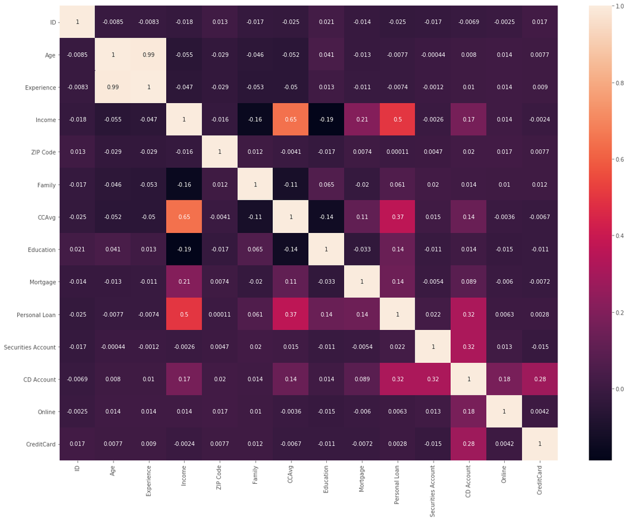

```python
# Heatmap version for correlation
sns.heatmap(dataset.corr(),annot=True)
```

### EDA Analysis:

- From the above correlation, we can say that Age and experience are highly correlated to each other. we can ignore this in our model training as it would not add much value to it.
- In terms of dependent variable, we can say that 'Personal Loan' is correlated with 'Income', 'CCAvg' adn possible 'CD Account' more than other columns.

#### Categorical distribution analysis

- Family size is fairly distributed, size 1 is having higher percentage around 30%,
- 42% of the candidates are Undergraduate, 28% are Graduate and 30% are Advance professional.
- Only 10% of the customers have a securities account with the bank.
- Only 6% of the customers have CD account with the bank.
- Approximately 60% of the customers use online banking. *Approximately 30% of the customers use a credit card.

##### From the data, we can say that approximately 10% of the customers end up taking personal loan.

### Univariate and Bivariate Analysis

```python
# We are interested in the dependent variable 'Personal Loan' and it's distribution among the other categories and values.

# Create function to avoid duplicate code

def plot_independent_dependent(independent,dependent='Personal Loan'):
    fig, axs = plt.subplots(1,2)
    plt.figure(figsize=(10,5))
    plot = sns.countplot(ax=axs[0],x=independent, hue='Personal Loan', data=dataset)
    for p in plot.patches:
        height = p.get_height()
        plot.text(p.get_x()+p.get_width()/2., height + 0.1,height ,ha="center")
    sns.countplot(ax=axs[1],x=independent,data=dataset)
```

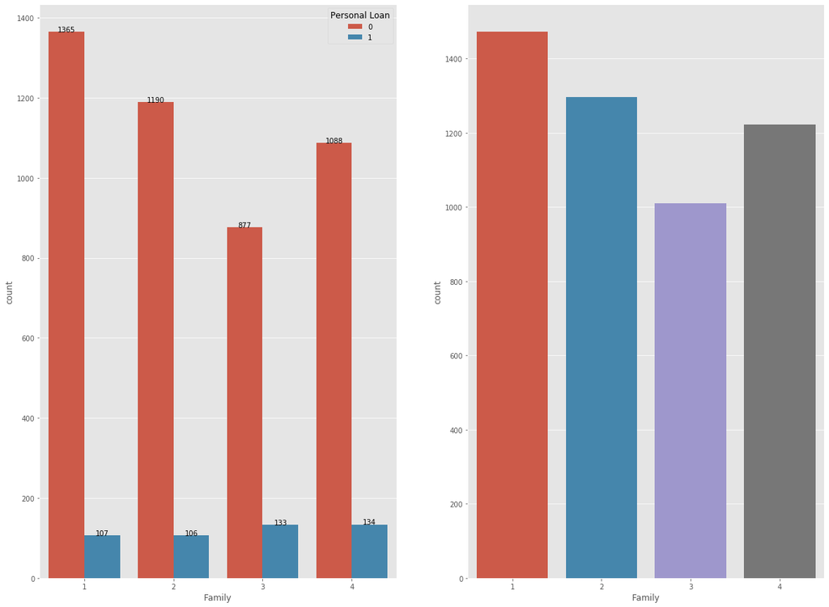

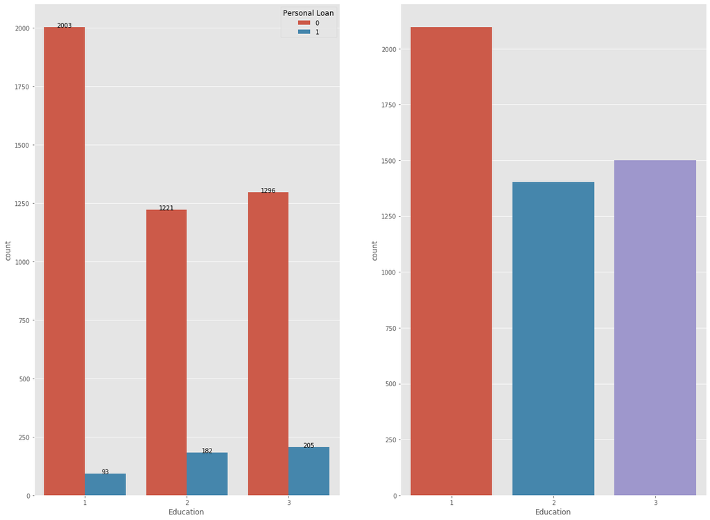

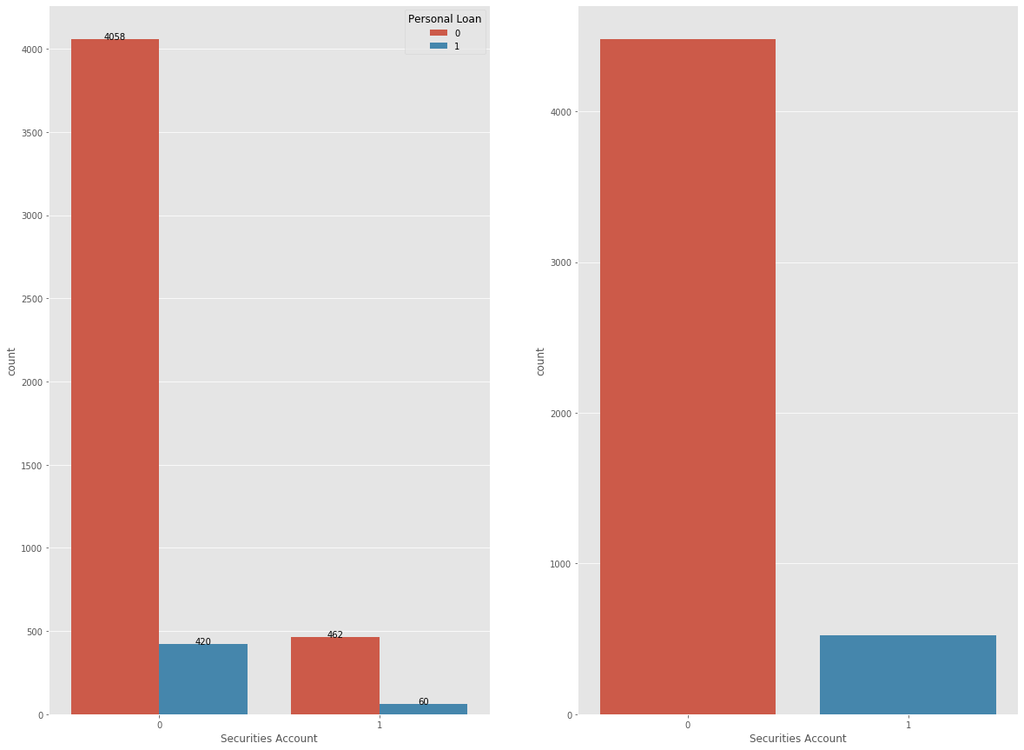

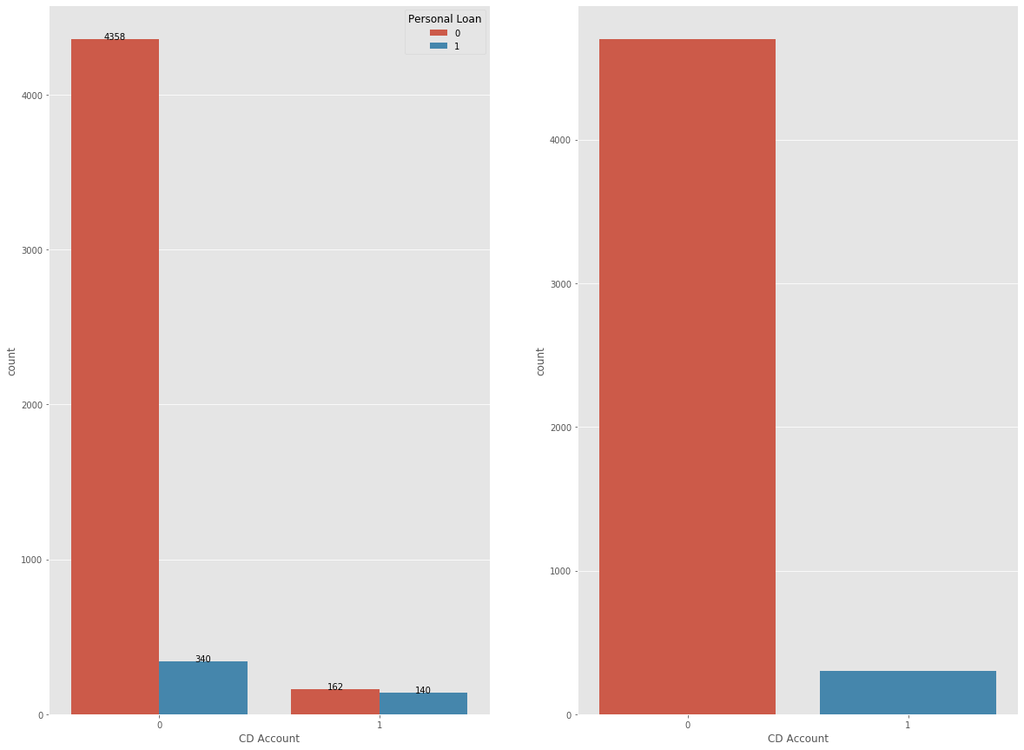

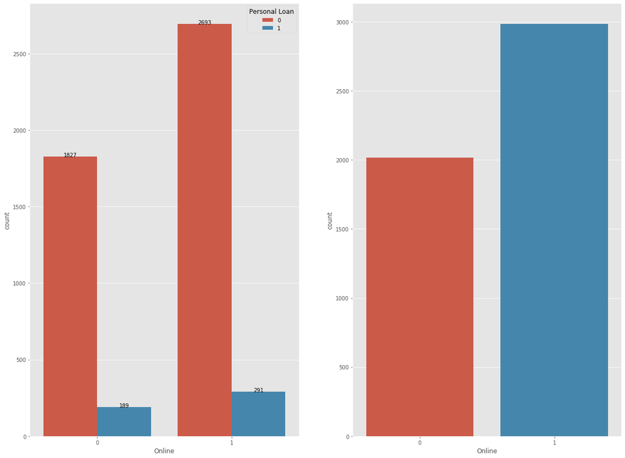

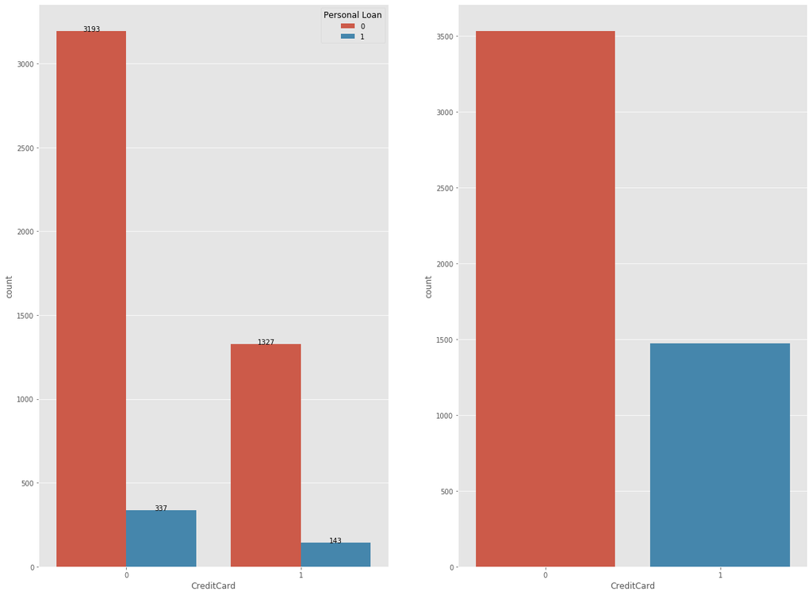

```python
# Plot graphs for interested categorical values
categories_columns.remove('Personal Loan')
for category in categories_columns:
    plot_independent_dependent(category)
```

```python
# Plot the 'Personal Loan' relationship with continuos values.

# Function to print distribution for continuos values.

def independent_cont_plot(category):
    fig, axs = plt.subplots(1,2)
    plt.figure(figsize=(10,5))

    # Display ditstribution plot
    sns.distplot(dataset[category],ax=axs[0],rug=True)

    # Display Bar plot to analyze the outliers
    sns.boxplot(dataset[category],ax=axs[1])
```

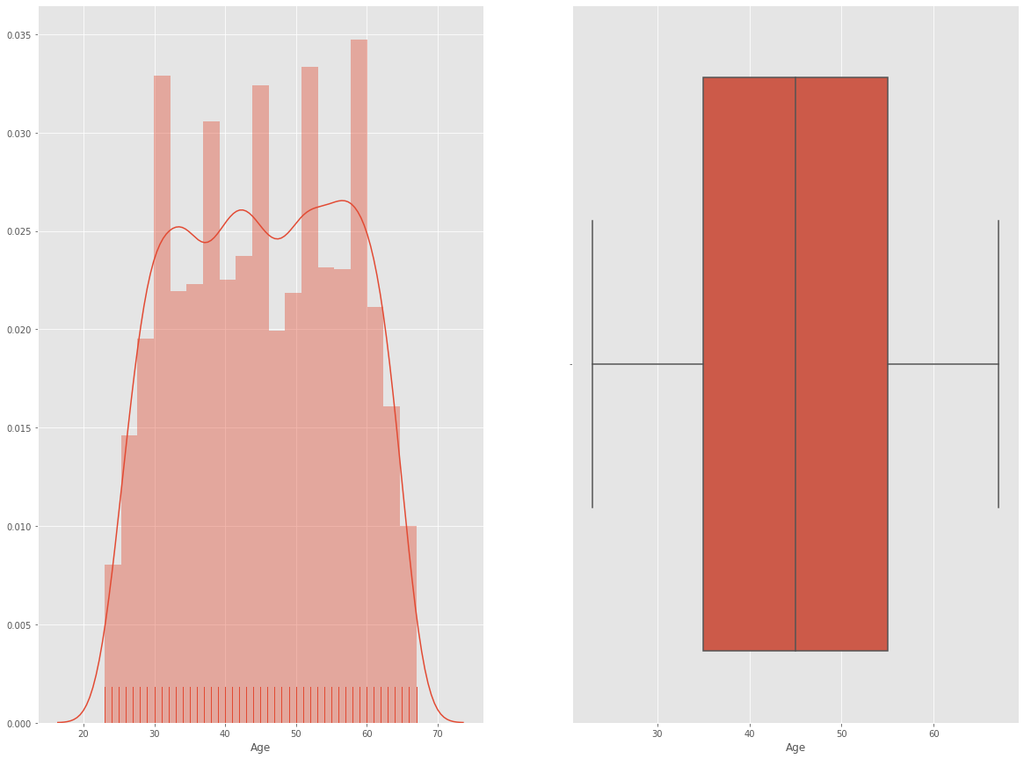

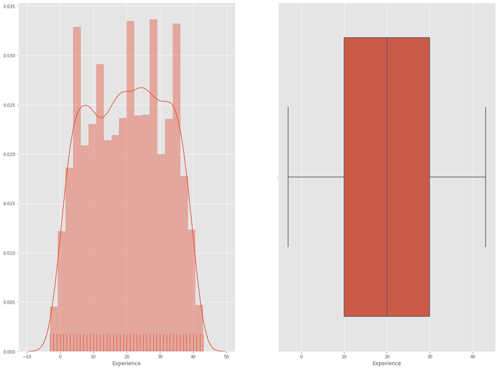

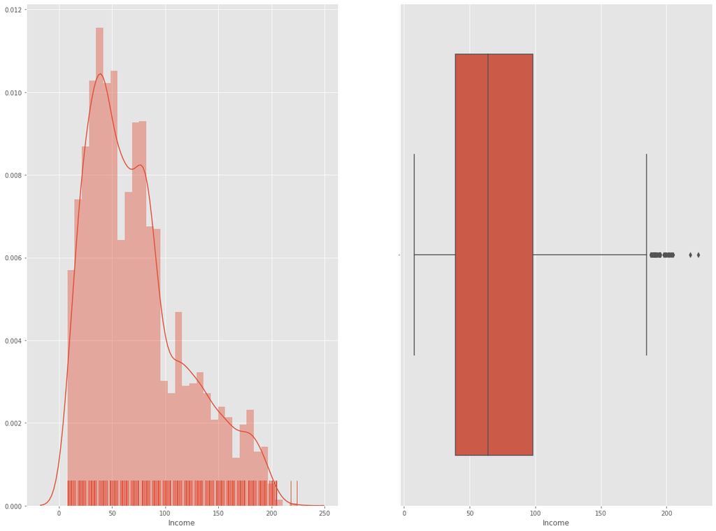

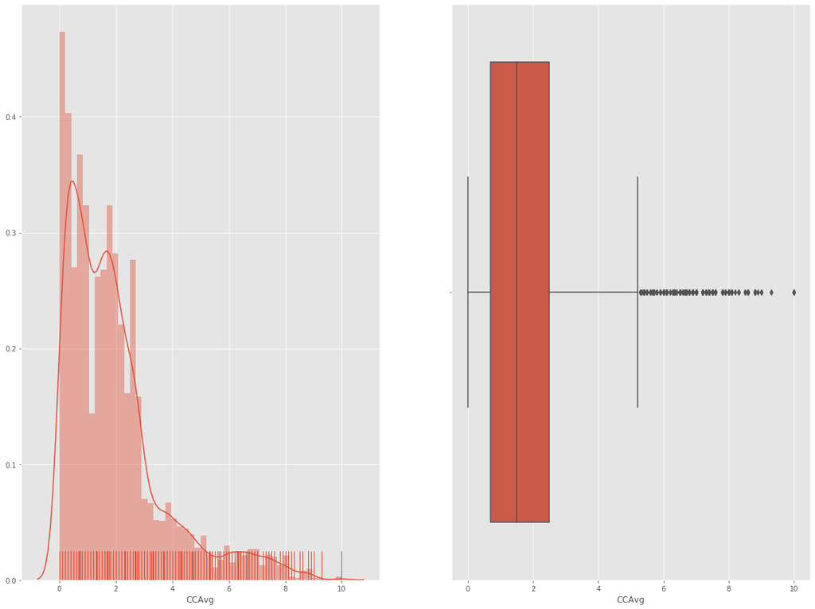

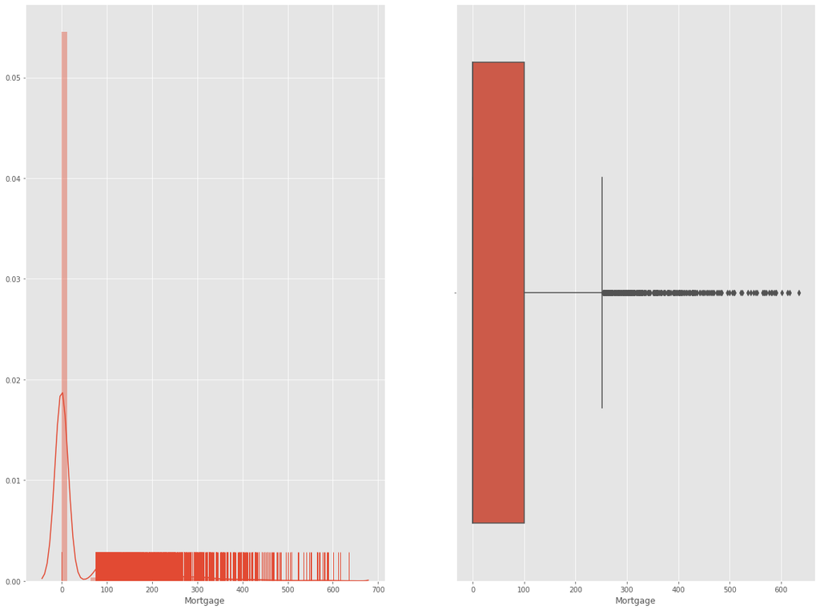

```python
# Print graphs for continuos values
continuous_columns=['Age','Experience','Income','CCAvg','Mortgage']

for category in continuous_columns:
    independent_cont_plot(category)
```

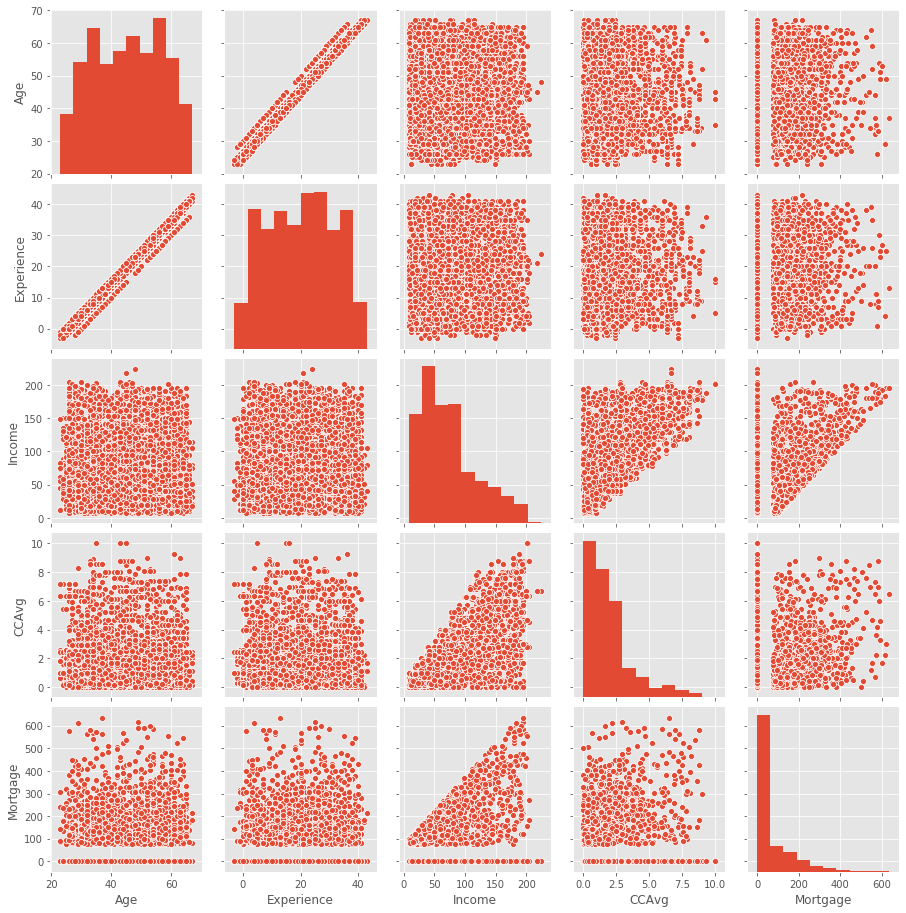

```python
# Pair plot to see the correlation of the continuous columns visually
sns.pairplot(dataset[continuous_columns])
```

### Analysis from the above Univariate and Bivariate plots

- From the above graph, we can see that the plots for Age, Experience are highly correlated to each other. They both have good distribution.
- Mortgage and CCAvg are highly skewed data. They also denotes good amount of outliers in them.

```python
# Continuos parameters average effect on Personal loan
def average_on_dependent(category):
    print("{1}\n".format(category,pd.pivot_table(dataset,values=category,index='Personal Loan',aggfunc='mean')))
```

```python
for category in continuous_columns:
    average_on_dependent(category)
```

```
                Age
Personal Loan
0             45.37
1             45.07

               Experience
Personal Loan
0                   20.13
1                   19.84

               Income
Personal Loan
0               66.24
1              144.75

               CCAvg
Personal Loan
0               1.73
1               3.91

               Mortgage
Personal Loan
0                 51.79
1                100.85
```

### Analysis:

- Age is fairly impact the personal loan decision. Average age of people getting loan is 45.
- Experience also has fair distribution. Average experienced person applying for loan is 20 years old.
- Average income of people applying for personal loan is 1,45,000. Lower income people tend to not apply for personal loan.
- Credit card spent for people applying for loan is higher than people not applying for it.
- People who applied for personal loan had higher motgage. People who have lower mortgage not needing any personal loan.

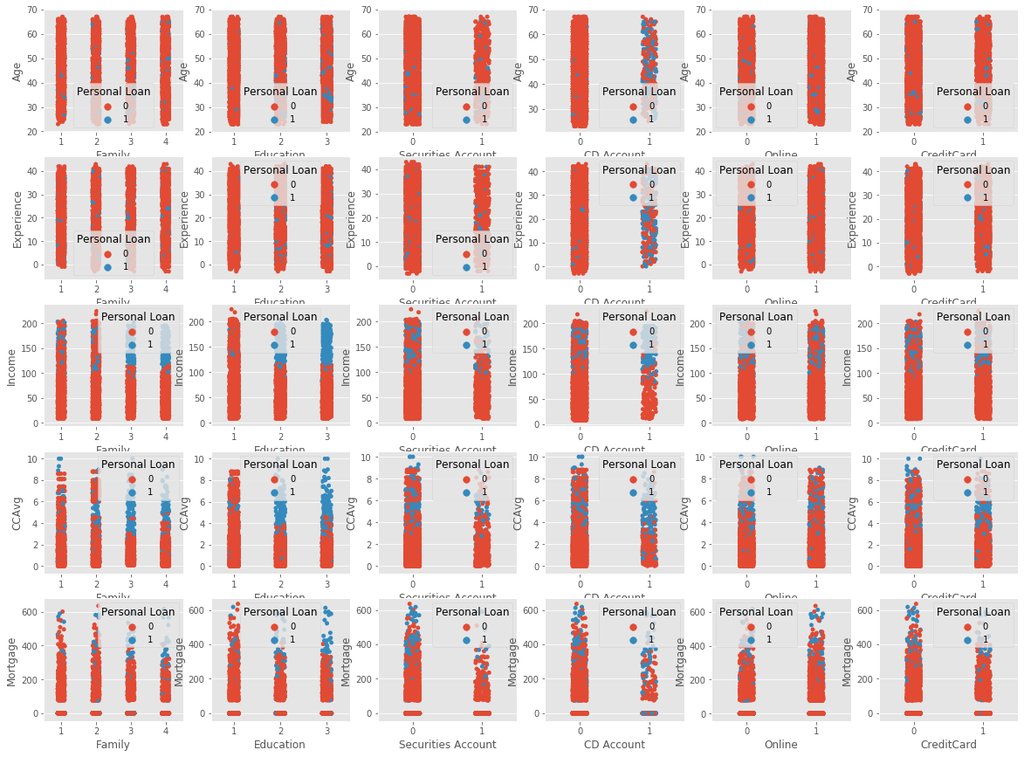

```python
#categories_columns = ['Family','Education','Securities Account','CD Account','Online','CreditCard']
#continuous_columns=['Age','Experience','Income','CCAvg','Mortgage']
plt.figure(figsize=(10,5))

fig, axs=plt.subplots(5,6)
for idx, cont in enumerate(continuous_columns):
    for idx1, cat in enumerate(categories_columns):
        sns.stripplot(ax=axs[idx,idx1],x=cat,y=cont, hue='Personal Loan', jitter=True,data=dataset)
```

### Analysis from above graph:

- Age & Experience have very much similar disrtibution for the Personal Loan choice.
- For income,
  - Family with size 3 and 4
  - Higher education, Graduate and Advanced professionals
  - CD Account with Higher income
  - Credit card with higher income buys more Personal Loan
- For CC Avg,
  - people with higher family members (3 or 4)
  - higher education
  - CD account
  - Doesn't have online account tend to have more Personal Loans.

### Get Data model ready

- Treat negative values for Experience
- Treat outliers for income, mortgage and CCAvg
- Categorical variables should be processeed with one-hot encoding

### Treat negative experiences

```python
# Treat the negative values as per ranges. We can not replace all values as mean because lowest age 23 cannot have experience 20 years.
dataset_modified = dataset.copy()
# User bins to do the intervals and then do the average of it and assign negative values to the average of that group.
# Take interval of 5's. minimum age 23, maximum age 67
bin_interval = [22, 27, 32, 37, 42, 47, 52, 57, 62, 68]
labels=['A', 'B', 'C','D', 'E', 'F','G','H', 'I']

dataset_modified['Age_bins'] = pd.cut(dataset_modified['Age'],bins=bin_interval, labels=labels)
avg=dataset_modified[dataset_modified['Experience']>0].groupby('Age_bins')['Experience'].mean().apply(np.ceil)
for x in dataset_modified[dataset_modified['Experience']<0].itertuples():
    dataset_modified.loc[x.Index,'Experience']=avg[x.Age_bins]
dataset_modified.drop('Age_bins',axis=1,inplace=True)
print("Negative Experience count:{0}".format(dataset_modified[dataset_modified['Experience']<0]['Experience'].count()))
dataset_modified.describe().T
```

```
Negative Experience count:0
```

|  | count | mean | std | min | 25% | 50% | 75% | max |
| --- | --- | --- | --- | --- | --- | --- | --- | --- |
| ID | 5,000.00 | 2,500.50 | 1,443.52 | 1.00 | 1,250.75 | 2,500.50 | 3,750.25 | 5,000.00 |
| Age | 5,000.00 | 45.34 | 11.46 | 23.00 | 35.00 | 45.00 | 55.00 | 67.00 |
| Experience | 5,000.00 | 20.14 | 11.40 | 0.00 | 10.00 | 20.00 | 30.00 | 43.00 |
| Income | 5,000.00 | 73.77 | 46.03 | 8.00 | 39.00 | 64.00 | 98.00 | 224.00 |
| ZIP Code | 5,000.00 | 93,152.50 | 2,121.85 | 9,307.00 | 91,911.00 | 93,437.00 | 94,608.00 | 96,651.00 |
| Family | 5,000.00 | 2.40 | 1.15 | 1.00 | 1.00 | 2.00 | 3.00 | 4.00 |
| CCAvg | 5,000.00 | 1.94 | 1.75 | 0.00 | 0.70 | 1.50 | 2.50 | 10.00 |
| Education | 5,000.00 | 1.88 | 0.84 | 1.00 | 1.00 | 2.00 | 3.00 | 3.00 |
| Mortgage | 5,000.00 | 56.50 | 101.71 | 0.00 | 0.00 | 0.00 | 101.00 | 635.00 |
| Personal Loan | 5,000.00 | 0.10 | 0.29 | 0.00 | 0.00 | 0.00 | 0.00 | 1.00 |
| Securities Account | 5,000.00 | 0.10 | 0.31 | 0.00 | 0.00 | 0.00 | 0.00 | 1.00 |
| CD Account | 5,000.00 | 0.06 | 0.24 | 0.00 | 0.00 | 0.00 | 0.00 | 1.00 |
| Online | 5,000.00 | 0.60 | 0.49 | 0.00 | 0.00 | 1.00 | 1.00 | 1.00 |
| CreditCard | 5,000.00 | 0.29 | 0.46 | 0.00 | 0.00 | 0.00 | 1.00 | 1.00 |

```python
dataset_modified.info()
```

```
<class 'pandas.core.frame.DataFrame'>
RangeIndex: 5000 entries, 0 to 4999
Data columns (total 14 columns):
 #   Column              Non-Null Count  Dtype
---  ------              --------------  -----
 0   ID                  5000 non-null   int64
 1   Age                 5000 non-null   int64
 2   Experience          5000 non-null   float64
 3   Income              5000 non-null   int64
 4   ZIP Code            5000 non-null   int64
 5   Family              5000 non-null   int64
 6   CCAvg               5000 non-null   float64
 7   Education           5000 non-null   int64
 8   Mortgage            5000 non-null   int64
 9   Personal Loan       5000 non-null   int64
 10  Securities Account  5000 non-null   int64
 11  CD Account          5000 non-null   int64
 12  Online              5000 non-null   int64
 13  CreditCard          5000 non-null   int64
dtypes: float64(2), int64(12)
memory usage: 547.0 KB
```

### Treat outliers using Robustscalar

```python
scaler = RobustScaler()
# Outliers are present in Income, CCAvg, Mortgage
candidates=['Income','CCAvg','Mortgage']
dataset_modified[candidates] = scaler.fit_transform(dataset_modified[candidates])
dataset_modified.head()
```

|  | ID | Age | Experience | Income | ZIP Code | Family | CCAvg | Education | Mortgage | Personal Loan | Securities Account | CD Account | Online | CreditCard |
| --- | --- | --- | --- | --- | --- | --- | --- | --- | --- | --- | --- | --- | --- | --- |
| 0 | 1 | 25 | 1.00 | -0.25 | 91107 | 4 | 0.06 | 1 | 0.00 | 0 | 1 | 0 | 0 | 0 |
| 1 | 2 | 45 | 19.00 | -0.51 | 90089 | 3 | 0.00 | 1 | 0.00 | 0 | 1 | 0 | 0 | 0 |
| 2 | 3 | 39 | 15.00 | -0.90 | 94720 | 1 | -0.28 | 1 | 0.00 | 0 | 0 | 0 | 0 | 0 |
| 3 | 4 | 35 | 9.00 | 0.61 | 94112 | 1 | 0.67 | 2 | 0.00 | 0 | 0 | 0 | 0 | 0 |
| 4 | 5 | 35 | 8.00 | -0.32 | 91330 | 4 | -0.28 | 2 | 0.00 | 0 | 0 | 0 | 0 | 1 |

### Apply onehot encoding

```python
# Change data type of multi categorical columns to category so that we can apply one-hot encoding there
dataset_modified['Education'] = dataset_modified['Education'].astype('category')
dataset_modified['Family'] = dataset_modified['Family'].astype('category')
dataset_modified.info()
```

```
<class 'pandas.core.frame.DataFrame'>
RangeIndex: 5000 entries, 0 to 4999
Data columns (total 14 columns):
 #   Column              Non-Null Count  Dtype
---  ------              --------------  -----
 0   ID                  5000 non-null   int64
 1   Age                 5000 non-null   int64
 2   Experience          5000 non-null   float64
 3   Income              5000 non-null   float64
 4   ZIP Code            5000 non-null   int64
 5   Family              5000 non-null   category
 6   CCAvg               5000 non-null   float64
 7   Education           5000 non-null   category
 8   Mortgage            5000 non-null   float64
 9   Personal Loan       5000 non-null   int64
 10  Securities Account  5000 non-null   int64
 11  CD Account          5000 non-null   int64
 12  Online              5000 non-null   int64
 13  CreditCard          5000 non-null   int64
dtypes: category(2), float64(4), int64(8)
memory usage: 478.9 KB
```

```python
# Apply one hot encoding
dataset_modified = pd.get_dummies(dataset_modified, drop_first=True)
dataset_modified.head()
```

|  | ID | Age | Experience | Income | ZIP Code | CCAvg | Mortgage | Personal Loan | Securities Account | CD Account | Online | CreditCard | Family_2 | Family_3 | Family_4 | Education_2 | Education_3 |
| --- | --- | --- | --- | --- | --- | --- | --- | --- | --- | --- | --- | --- | --- | --- | --- | --- | --- |
| 0 | 1 | 25 | 1.00 | -0.25 | 91107 | 0.06 | 0.00 | 0 | 1 | 0 | 0 | 0 | 0 | 0 | 1 | 0 | 0 |
| 1 | 2 | 45 | 19.00 | -0.51 | 90089 | 0.00 | 0.00 | 0 | 1 | 0 | 0 | 0 | 0 | 1 | 0 | 0 | 0 |
| 2 | 3 | 39 | 15.00 | -0.90 | 94720 | -0.28 | 0.00 | 0 | 0 | 0 | 0 | 0 | 0 | 0 | 0 | 0 | 0 |
| 3 | 4 | 35 | 9.00 | 0.61 | 94112 | 0.67 | 0.00 | 0 | 0 | 0 | 0 | 0 | 0 | 0 | 0 | 1 | 0 |
| 4 | 5 | 35 | 8.00 | -0.32 | 91330 | -0.28 | 0.00 | 0 | 0 | 0 | 0 | 1 | 0 | 0 | 1 | 1 | 0 |

```python
# Drop ID, ZIP CODE as they are unique for each item.
# Age & Experience are highly correlated. We will drop Experience.
dataset_modified.drop(['ID','ZIP Code','Experience'],axis=1,inplace=True)
dataset_modified.head()
```

|  | Age | Income | CCAvg | Mortgage | Personal Loan | Securities Account | CD Account | Online | CreditCard | Family_2 | Family_3 | Family_4 | Education_2 | Education_3 |
| --- | --- | --- | --- | --- | --- | --- | --- | --- | --- | --- | --- | --- | --- | --- |
| 0 | 25 | -0.25 | 0.06 | 0.00 | 0 | 1 | 0 | 0 | 0 | 0 | 0 | 1 | 0 | 0 |
| 1 | 45 | -0.51 | 0.00 | 0.00 | 0 | 1 | 0 | 0 | 0 | 0 | 1 | 0 | 0 | 0 |
| 2 | 39 | -0.90 | -0.28 | 0.00 | 0 | 0 | 0 | 0 | 0 | 0 | 0 | 0 | 0 | 0 |
| 3 | 35 | 0.61 | 0.67 | 0.00 | 0 | 0 | 0 | 0 | 0 | 0 | 0 | 0 | 1 | 0 |
| 4 | 35 | -0.32 | -0.28 | 0.00 | 0 | 0 | 0 | 0 | 1 | 0 | 0 | 1 | 1 | 0 |

## Step 3: Split the data into training and test set in the ratio of 70:30 respectively (5 marks)

```python
## Define X and Y variables
X = dataset_modified.drop('Personal Loan', axis=1)
Y = dataset_modified[['Personal Loan']]

X_train, X_test, y_train, y_test = train_test_split(X, Y, test_size=0.30,random_state=19)

dataset_modified.nunique()
```

```
Age                    45
Income                162
CCAvg                 108
Mortgage              347
Personal Loan           2
Securities Account      2
CD Account              2
Online                  2
CreditCard              2
Family_2                2
Family_3                2
Family_4                2
Education_2             2
Education_3             2
dtype: int64
```

```python
print(y_train[y_train['Personal Loan']==0].count())
# Print values of Personal loan data in Train/test sets.
print("Training set: {0:0.2f}% ".format((len(X_train)/len(dataset_modified.index)) * 100))
print("Testing set: {0:0.2f}%".format((len(X_test)/len(dataset_modified.index)) * 100))
# Print Personal Loan values:
print("\n")
print("Personal Loan True Values(Originally)             : {0} ({1:0.2f}%)\n".format(len(dataset_modified.loc[dataset_modified['Personal Loan'] == 1]), (len(dataset_modified.loc[dataset_modified['Personal Loan'] == 1])/len(dataset_modified.index)) * 100))
print("Personal Loan False Values(Originally)            : {0} ({1:0.2f}%)\n".format(len(dataset_modified.loc[dataset_modified['Personal Loan'] == 0]), (len(dataset_modified.loc[dataset_modified['Personal Loan'] == 0])/len(dataset_modified.index)) * 100))
print("Personal Loan False Values (Tarining)             : {0} ({1:0.2f}%)\n".format(len(y_train[y_train['Personal Loan'] == 0]), (len(y_train[y_train['Personal Loan'] == 0])/len(y_train)) * 100))
print("Personal Loan True Values (Testing)               : {0} ({1:0.2f}%)\n".format(len(y_test[y_test['Personal Loan'] == 1]), (len(y_test[y_test['Personal Loan'] == 1])/len(y_test)) * 100))
print("Personal Loan False Values (Testing)              : {0} ({1:0.2f}%)\n".format(len(y_test[y_test['Personal Loan'] == 0]), (len(y_test[y_test['Personal Loan'] == 0])/len(y_test)) * 100))
```

```
Personal Loan    3172
dtype: int64
Training set: 70.00%
Testing set: 30.00%


Personal Loan True Values(Originally)             : 480 (9.60%)

Personal Loan False Values(Originally)            : 4520 (90.40%)

Personal Loan False Values (Tarining)             : 3172 (90.63%)

Personal Loan True Values (Testing)               : 152 (10.13%)

Personal Loan False Values (Testing)              : 1348 (89.87%)
```

## Step 3: Use Logistic Regression model to predict whether the customer will take personal loan or not. Print all the metrics related for evaluating the model performance (15 marks)

### Logistic regression model using sklearn

```python
## Model training
logreg = LogisticRegression(random_state=42,C=0.5)
logreg.fit(X_train, y_train)
```

```
LogisticRegression(C=0.5, class_weight=None, dual=False, fit_intercept=True,
                   intercept_scaling=1, l1_ratio=None, max_iter=100,
                   multi_class='auto', n_jobs=None, penalty='l2',
                   random_state=42, solver='lbfgs', tol=0.0001, verbose=0,
                   warm_start=False)
```

```python
y_predict = logreg.predict(X_test)
```

```python
## function to get confusion matrix in a proper format
def draw_cm( actual, predicted ):
    cm = confusion_matrix( actual, predicted)
    plt.figure(figsize=(10,5))
    sns.heatmap(cm, annot=True,  fmt='.2f', xticklabels = [0,1] , yticklabels = [0,1] )
    plt.ylabel('Observed')
    plt.xlabel('Predicted')
```

```
Trainig accuracy 0.9577142857142857

Testing accuracy 0.958

Confusion Matrix
None

Recall: 0.6381578947368421

Precision: 0.9238095238095239

F1 Score: 0.754863813229572

Roc Auc Score: 0.8161115883179759
```

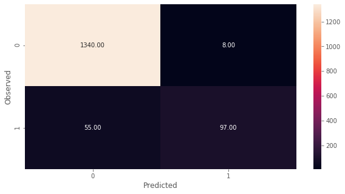

```python
print("Trainig accuracy",logreg.score(X_train,y_train))
print()
print("Testing accuracy",logreg.score(X_test, y_test))
print()
print('Confusion Matrix')
print(draw_cm(y_test,y_predict))
print()
print("Recall:",recall_score(y_test,y_predict))
print()
print("Precision:",precision_score(y_test,y_predict))
print()
print("F1 Score:",f1_score(y_test,y_predict))
print()
print("Roc Auc Score:",roc_auc_score(y_test,y_predict))
```

### Analysis:

- True Positives(TP): Number of people we predicted would take personal loan, end up taking 97
- True Negative(TN): Number of people we predicted would not take personal loan, end up not taking 1340
- False Positive(FP) or Type I error: Number of people we predicted would take loan, end up not taking 8
- False Negative(FN) or Type II error: Number of people we predicted would not take loan, end up taking 55

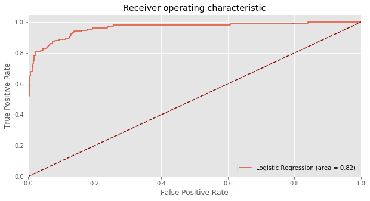

```python
#AUC ROC curve
logit_roc_auc = roc_auc_score(y_test, logreg.predict(X_test))
fpr, tpr, thresholds = roc_curve(y_test, logreg.predict_proba(X_test)[:,1])
plt.figure(figsize=(10,5))
plt.plot(fpr, tpr, label='Logistic Regression (area = %0.2f)' % logit_roc_auc)
plt.plot([0, 1], [0, 1],'r--')
plt.xlim([0.0, 1.0])
plt.ylim([0.0, 1.05])
plt.xlabel('False Positive Rate')
plt.ylabel('True Positive Rate')
plt.title('Receiver operating characteristic')
plt.legend(loc="lower right")
plt.savefig('Log_ROC')
plt.show()
```

```python
print(classification_report(y_test, y_predict))
```

```
              precision    recall  f1-score   support

           0       0.96      0.99      0.98      1348
           1       0.92      0.64      0.75       152

    accuracy                           0.96      1500
   macro avg       0.94      0.82      0.87      1500
weighted avg       0.96      0.96      0.95      1500
```

### Analysis:

- From the above parameters, we can make some conclusion on our model:
  - Accuracy: 96%
  - Recall: 64%
  - Precision: 92%

## Logistic regressionusing stats model

```python
# Build model

logit = sm.Logit(y_train, sm.add_constant(X_train))
lg = logit.fit()
```

```
Optimization terminated successfully.
         Current function value: 0.111466
         Iterations 9
```

```python
stats.chisqprob = lambda chisq, df: stats.chi2.sf(chisq, df)
print(lg.summary())
```

```
                           Logit Regression Results
==============================================================================
Dep. Variable:          Personal Loan   No. Observations:                 3500
Model:                          Logit   Df Residuals:                     3486
Method:                           MLE   Df Model:                           13
Date:                Fri, 10 Jul 2020   Pseudo R-squ.:                  0.6416
Time:                        23:55:34   Log-Likelihood:                -390.13
converged:                       True   LL-Null:                       -1088.7
Covariance Type:            nonrobust   LLR p-value:                6.540e-291
======================================================================================
                         coef    std err          z      P>|z|      [0.025      0.975]
--------------------------------------------------------------------------------------
const                 -9.2467      0.638    -14.500      0.000     -10.497      -7.997
Age                    0.0131      0.008      1.542      0.123      -0.004       0.030
Income                 3.7295      0.224     16.671      0.000       3.291       4.168
CCAvg                  0.3370      0.099      3.389      0.001       0.142       0.532
Mortgage               0.0799      0.073      1.093      0.275      -0.063       0.223
Securities Account    -0.5464      0.355     -1.540      0.123      -1.242       0.149
CD Account             3.5515      0.401      8.859      0.000       2.766       4.337
Online                -0.7592      0.204     -3.716      0.000      -1.160      -0.359
CreditCard            -0.8581      0.258     -3.327      0.001      -1.364      -0.353
Family_2               0.0455      0.279      0.163      0.870      -0.501       0.592
Family_3               2.0655      0.311      6.642      0.000       1.456       2.675
Family_4               1.5912      0.298      5.341      0.000       1.007       2.175
Education_2            3.9960      0.338     11.810      0.000       3.333       4.659
Education_3            4.1894      0.334     12.543      0.000       3.535       4.844
======================================================================================

Possibly complete quasi-separation: A fraction 0.13 of observations can be
perfectly predicted. This might indicate that there is complete
quasi-separation. In this case some parameters will not be identified.
```

### Interpretation of Pseudo R^2¶

- A pseudo R^2 of 64.1% indicates that 64.1% of the uncertainty of the intercept only model is explained by the full model

```python
#Calculate Odds Ratio, probability
##create a data frame to collate Odds ratio, probability and p-value of the coef
lgcoef = pd.DataFrame(lg.params, columns=['coef'])
lgcoef.loc[:, "Odds_ratio"] = np.exp(lgcoef.coef)
lgcoef['probability'] = lgcoef['Odds_ratio']/(1+lgcoef['Odds_ratio'])
lgcoef['pval']=lg.pvalues
pd.options.display.float_format = '{:.2f}'.format
```

```python
# Filter by significant p-value (pval <0.1) and sort descending by Odds ratio
lgcoef = lgcoef.sort_values(by="Odds_ratio", ascending=False)
pval_filter = lgcoef['pval']<=0.1
lgcoef[pval_filter]
```

|  | coef | Odds_ratio | probability | pval |
| --- | --- | --- | --- | --- |
| Education_3 | 4.19 | 65.98 | 0.99 | 0.00 |
| Education_2 | 4.00 | 54.38 | 0.98 | 0.00 |
| Income | 3.73 | 41.66 | 0.98 | 0.00 |
| CD Account | 3.55 | 34.86 | 0.97 | 0.00 |
| Family_3 | 2.07 | 7.89 | 0.89 | 0.00 |
| Family_4 | 1.59 | 4.91 | 0.83 | 0.00 |
| CCAvg | 0.34 | 1.40 | 0.58 | 0.00 |
| Online | -0.76 | 0.47 | 0.32 | 0.00 |
| CreditCard | -0.86 | 0.42 | 0.30 | 0.00 |
| const | -9.25 | 0.00 | 0.00 | 0.00 |

### Analysis:

- From the above stats, we can see the impact of independent variables on the Personal Loan.
  - Higher graduation has the highest impact on the loan status (~98%)
  - Income has equal importance for loan (~98%)
  - CD Account has the 97% effect on personal loan.

## Step 4: Give your reasoning on how can the model perform better? (10 marks)

### Model imporvements:

- Model can be improved several ways by changing some of the parameters that we have used above to build our model. As per out LogisticRegression model above, we used parameters such as C, penalty, solver to configure the model building. We can play with these values and check which turns out to be the best for our case.

#### Output Analysis:

- As described above, looking at confusion matrix we can learn the number of TP, TN, FP, FN. As we are trying to build model that can predict the Personal loan success rate, we need to focus on our type II error. False Negative is 55. This means we predicted that the people want apply for Personal loan but they end up taking it. We missed the business opportunity there. Ideally, out model should be predicted all situation right or we should have 0 FP and 0 FP. For out business model we need to have smallest number of type II error.

#### Parameters descriptions:

##### penalty{‘l1’, ‘l2’, ‘elasticnet’, ‘none’}, default=’l2’

- Used to specify the norm used in the penalization. The ‘newton-cg’, ‘sag’ and ‘lbfgs’ solvers support only l2 penalties. ‘elasticnet’ is only supported by the ‘saga’ solver. If ‘none’ (not supported by the liblinear solver), no regularization is applied.

##### dualbool, default=False

- Dual formulation is only implemented for l2 penalty with liblinear solver. Prefer dual=False when n_samples > n_features.

##### tolfloat, default=1e-4

- Tolerance for stopping criteria.

##### Cfloat, default=1.0

- Inverse of regularization strength

##### fit_interceptbool, default=True

- Specifies if a constant (a.k.a. bias or intercept) should be added to the decision function.

##### intercept_scalingfloat, default=1

- Useful only when the solver ‘liblinear’ is used and self.fit_intercept is set to True.

##### class_weightdict or ‘balanced’, default=None

- Weights associated with classes in the form {class_label: weight}. If not given, all classes are supposed to have weight one.

##### random_stateint, RandomState instance, default=None

- Used when solver == ‘sag’, ‘saga’ or ‘liblinear’ to shuffle the data.

##### solver{‘newton-cg’, ‘lbfgs’, ‘liblinear’, ‘sag’, ‘saga’}, default=’lbfgs’

- Algorithm to use in the optimization problem. For small datasets, ‘liblinear’ is a good choice, whereas ‘sag’ and ‘saga’ are faster for large ones. liblinear looks much better for our case of Personal Loan.
- ‘newton-cg’, ‘lbfgs’, ‘sag’ and ‘saga’ handle L2 or no penalty
- ‘liblinear’ and ‘saga’ also handle L1 penalty
- ‘saga’ also supports ‘elasticnet’ penalty
- ‘liblinear’ does not support setting penalty='none'

##### max_iterint, default=100

- Maximum number of iterations taken for the solvers to converge.

##### multi_class{‘auto’, ‘ovr’, ‘multinomial’}, default=’auto’

- If the option chosen is ‘ovr’, then a binary problem is fit for each label

##### verboseint, default=0

- For the liblinear and lbfgs solvers set verbose to any positive number for verbosity.

##### warm_startbool, default=False

When set to True, reuse the solution of the previous call to fit as initialization, otherwise, just erase the previous solution. Useless for liblinear solver.

##### n_jobsint, default=None

- Number of CPU cores used when parallelizing over classes if multi_class=’ovr’”. This parameter is ignored when the solver is set to ‘liblinear’ regardless of whether ‘multi_class’ is specified or not.

##### l1_ratiofloat, default=None

- The Elastic-Net mixing parameter, with 0 <= l1_ratio <= 1. Only used if penalty='elasticnet'.

##### Reference: https://scikit-learn.org/stable/modules/generated/sklearn.linear_model.LogisticRegression.html

```python
# Get the previous params used to build model
logreg.get_params()
```

```
{'C': 0.5,
 'class_weight': None,
 'dual': False,
 'fit_intercept': True,
 'intercept_scaling': 1,
 'l1_ratio': None,
 'max_iter': 100,
 'multi_class': 'auto',
 'n_jobs': None,
 'penalty': 'l2',
 'random_state': 42,
 'solver': 'lbfgs',
 'tol': 0.0001,
 'verbose': 0,
 'warm_start': False}
```

```python
# Function that can test multiple solvers with multiple C values and other params we got above.

column_params_types = [('solver', str),
             ('penalty', str),
             ('multi_class', str),
             ('dual', bool),
             ('fit_intercept', bool),
             ('class_weight', str),
             ('C', np.float128),
             ('train score', np.float128), ('test score', np.float128),
             ('recall score', np.float128),
             ('precision score', np.float128),
             ('roc auc score', np.float128)]

# Lets create dataframes one with type and one without.
dataset_compare_type = pd.DataFrame({x: pd.Series(dtype=y) for x, y in column_params_types})
#initialize params
idx = 0
rows_list = []

def all_params_regression():

    # Initialize defaults first
    train_accuracy = 0.0
    # Test
    test_accuracy = 0.0
    test_rscore = 0.0
    test_pscore = 0.0
    test_auc = 0.0

    # Vars
    global idx
    global rows_list

    global dataset_compare_type

    C = [0.01,0.1,0.25,0.5,0.75,1]
    solver = ['newton-cg', 'lbfgs', 'liblinear', 'sag', 'saga']
    penalties = ['l1', 'l2', 'elasticnet', 'none']
    multi_class = ['ovr', 'multinomial', 'auto']
    cweight = ['balanced', None]
    dual = [True, False]
    fit_intercept = [True, False]

    for s in solver:
        for p in penalties:
            for mc in multi_class:
                for d in dual:
                    for fit in fit_intercept:
                        for cw in cweight:
                            for c in C:
                                logreg_fn = LogisticRegression(solver=s,
                                                            max_iter=1000,
                                                            penalty=p,
                                                            dual=d,
                                                            fit_intercept=fit,
                                                            class_weight=cw,
                                                            C=c,
                                                            random_state=42)

                                if s == 'newton-cg' and p not in ('l2', 'none'):
                                    continue

                                if s == 'newton-cg' and d == True:
                                    continue

                                if s == 'lbfgs' and p not in ('l2', 'none'):
                                    continue

                                if s == 'lbfgs' and d == True:
                                    continue

                                if p == 'l1' and d == True:
                                    continue

                                if s != 'saga' and p == 'elasticnet':
                                    continue

                                if s == 'liblinear' and p == 'none':
                                    continue

                                if s == 'sag' and p not in ('l2', 'none'):
                                    continue

                                if s == 'sag' and d == True:
                                    continue

                                if s == 'saga' and d == True:
                                    continue

                                if s == 'saga' and p == 'elasticnet' and d == False:
                                    continue

                                logreg_fn.fit(X_train, y_train)

                                logreg_score_train = logreg_fn.score(X_train, y_train)

                                logreg_score_test = logreg_fn.score(X_test, y_test)

                                y_predict = logreg.predict(X_test)

                                rscore = recall_score(y_test,y_predict)

                                pscore = precision_score(y_test,y_predict)

                                f1 = f1_score(y_test,y_predict)

                                roc = roc_auc_score(y_test,y_predict)

                                data_modified = {'solver':s,
                                                 'penalty': p,
                                                 'multi_class': mc,
                                                 'dual': d,
                                                 'fit_intercept': fit,
                                                 'class_weight': cw, 'C':c,
                                                 'train score': logreg_score_train,
                                                 'test score': logreg_score_test,
                                                 'recall score': rscore,
                                                 'precision score': pscore,
                                                 'roc auc score': roc}

                                #
                                # Choose highest accuracy model
                                #
                                if (logreg_score_test >= test_accuracy and logreg_score_train >= train_accuracy):
                                    train_accuracy = logreg_score_train
                                    test_accuracy = logreg_score_test
                                    test_rscore = rscore
                                    test_pscore = pscore
                                    test_auc = roc
                                    dataset_compare_type = dataset_compare_type.append([data_modified], ignore_index=True)


all_params_regression()
```

```python
# We should have results for all different combinations of params and logistic mode score values from above.
dataset_compare_type.sort_values(['recall score',
                                  'precision score',
                                  'roc auc score',
                                  'train score',
                                  'test score'],ascending=[False, False, False, False, False]).head(25)
```

|  | solver | penalty | multi_class | dual | fit_intercept | class_weight | C | train score | test score | recall score | precision score | roc auc score |
| --- | --- | --- | --- | --- | --- | --- | --- | --- | --- | --- | --- | --- |
| 20 | sag | none | ovr | False | True | None | 0.01 | 0.96 | 0.96 | 0.64 | 0.92 | 0.82 |
| 21 | sag | none | ovr | False | True | None | 0.10 | 0.96 | 0.96 | 0.64 | 0.92 | 0.82 |
| 22 | sag | none | ovr | False | True | None | 0.25 | 0.96 | 0.96 | 0.64 | 0.92 | 0.82 |
| 23 | sag | none | ovr | False | True | None | 0.50 | 0.96 | 0.96 | 0.64 | 0.92 | 0.82 |
| 24 | sag | none | ovr | False | True | None | 0.75 | 0.96 | 0.96 | 0.64 | 0.92 | 0.82 |
| 25 | sag | none | ovr | False | True | None | 1.00 | 0.96 | 0.96 | 0.64 | 0.92 | 0.82 |
| 26 | sag | none | multinomial | False | True | None | 0.01 | 0.96 | 0.96 | 0.64 | 0.92 | 0.82 |
| 27 | sag | none | multinomial | False | True | None | 0.10 | 0.96 | 0.96 | 0.64 | 0.92 | 0.82 |
| 28 | sag | none | multinomial | False | True | None | 0.25 | 0.96 | 0.96 | 0.64 | 0.92 | 0.82 |
| 29 | sag | none | multinomial | False | True | None | 0.50 | 0.96 | 0.96 | 0.64 | 0.92 | 0.82 |
| 30 | sag | none | multinomial | False | True | None | 0.75 | 0.96 | 0.96 | 0.64 | 0.92 | 0.82 |
| 31 | sag | none | multinomial | False | True | None | 1.00 | 0.96 | 0.96 | 0.64 | 0.92 | 0.82 |
| 32 | sag | none | auto | False | True | None | 0.01 | 0.96 | 0.96 | 0.64 | 0.92 | 0.82 |
| 33 | sag | none | auto | False | True | None | 0.10 | 0.96 | 0.96 | 0.64 | 0.92 | 0.82 |
| 34 | sag | none | auto | False | True | None | 0.25 | 0.96 | 0.96 | 0.64 | 0.92 | 0.82 |
| 35 | sag | none | auto | False | True | None | 0.50 | 0.96 | 0.96 | 0.64 | 0.92 | 0.82 |
| 36 | sag | none | auto | False | True | None | 0.75 | 0.96 | 0.96 | 0.64 | 0.92 | 0.82 |
| 37 | sag | none | auto | False | True | None | 1.00 | 0.96 | 0.96 | 0.64 | 0.92 | 0.82 |
| 14 | liblinear | l1 | ovr | False | True | None | 0.75 | 0.96 | 0.96 | 0.64 | 0.92 | 0.82 |
| 15 | liblinear | l1 | ovr | False | True | None | 1.00 | 0.96 | 0.96 | 0.64 | 0.92 | 0.82 |
| 16 | liblinear | l1 | multinomial | False | True | None | 0.75 | 0.96 | 0.96 | 0.64 | 0.92 | 0.82 |
| 17 | liblinear | l1 | multinomial | False | True | None | 1.00 | 0.96 | 0.96 | 0.64 | 0.92 | 0.82 |
| 18 | liblinear | l1 | auto | False | True | None | 0.75 | 0.96 | 0.96 | 0.64 | 0.92 | 0.82 |
| 19 | liblinear | l1 | auto | False | True | None | 1.00 | 0.96 | 0.96 | 0.64 | 0.92 | 0.82 |
| 13 | liblinear | l1 | ovr | False | True | None | 0.50 | 0.96 | 0.96 | 0.64 | 0.92 | 0.82 |

```
Trainig accuracy 0.9568571428571429

Testing accuracy 0.96

Confusion Matrix
None

Recall: 0.6447368421052632

Precision: 0.9423076923076923

F1 Score: 0.765625

Roc Auc Score: 0.8201429017647978
```

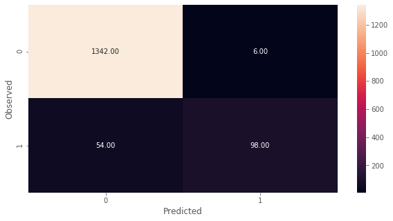

```python
# From the above table, we ge the best parameter that we can use to train our model.
logreg_final = LogisticRegression(random_state=42, solver='liblinear', multi_class='ovr', dual=False,
                           C=1, class_weight=None, fit_intercept=True)
logreg_final.fit(X_train, y_train)
y_predict = logreg_final.predict(X_test)
print("Trainig accuracy",logreg_final.score(X_train,y_train))
print()
print("Testing accuracy",logreg_final.score(X_test, y_test))
print()
print('Confusion Matrix')
print(draw_cm(y_test,y_predict))
print()
print("Recall:",recall_score(y_test,y_predict))
print()
print("Precision:",precision_score(y_test,y_predict))
print()
print("F1 Score:",f1_score(y_test,y_predict))
print()
print("Roc Auc Score:",roc_auc_score(y_test,y_predict))
```

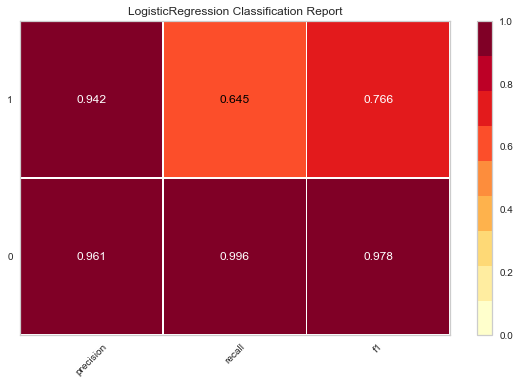

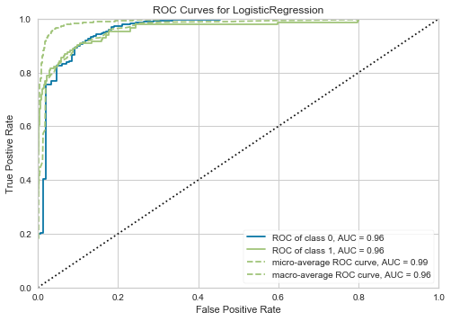

```python
from yellowbrick.classifier import ClassificationReport, ROCAUC
# Visualize model performance with yellowbrick library
viz = ClassificationReport(logreg_final)
viz.fit(X_train, y_train)
viz.score(X_test, y_test)
viz.show()

roc = ROCAUC(logreg_final)
roc.fit(X_train, y_train)
roc.score(X_test, y_test)
roc.show()
```

## Step 5: Give Business understanding and final analysis

### Business Understanding:

- As we know, here the Thera bank is asking for the Machine learning solution based on the past data to convert it's liability customers to the Personal loan applicants. To do that, they would like to identify the right customers or we can say potential candidates who can apply for the Personal loan. Also, bank would like to spend their marketing money wisely and such that maximum people gets approved for Personal loan and bank won't waste money.
- Based on our above final model, our accuracy for the model is around 96%, which is very high. For us, not just accuracy but recall and precision plays equal amount of role in it. We would like to reduce type II error in this case. False Negative plays crucial role. It means we predicted the audience who won'r buy personal loan but they end up buying personal loan. This number should be as small as possible so that Bank would get enough business. We can see the values for these parametes from the above confusion matrix.
  - TP: 98
  - TN: 1342
  - FP: 6
  - FN: 54
- Also, I would like to call out the best audience to reach out for the marketing from above visualizations. Bank should target people with higher family size, higher income, higher credit card spendings. They tend to apply for Personal loan more often from the rest of the combinations.
- Hence proved!